# Otros instrumentos de medición y control

## Introducción

En todo trabajo técnico es fundamental medir con precisión. Existen diversos instrumentos según lo que queramos medir. Aquí veremos algunos de los más comunes salvo el calibre Vernier que tiene una lección aparte.

## Regla metálica (Steel Ruler)

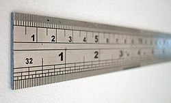

Regla graduada en milímetros y pulgadas - Fuente: Wikipedia

Generalmente en el taller se usa la regla metálica para medir longitudes simples. La precición más común es la de 1 mm. Esto significa que cada rayita está separada por un un milímeto. Puede venir graduada también en pulgadas. También sirve para trazar líneas sobre la pieza que se trabaja.

## Escuadra fija de 90° (Fixed 90° Square)

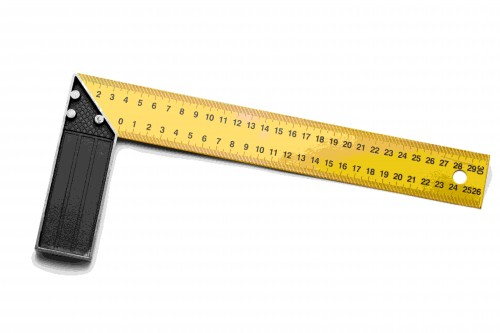

Escuadra fija - Fuente: Wikipedia

Es un instrumento utilizado para **verificar ángulos rectos (90°)** entre dos superficies.

**Usos principales:**

- Verificar si una esquina forma un ángulo recto.
- Trazar líneas perpendiculares en trabajos de marcado.
- **Comprobar la rectitud o planitud** de una superficie, apoyando la escuadra y observando si hay paso de luz o separación.

**Precauciones:**

- Evitar golpes que puedan desalinearla.
- Guardarla en lugar protegido para que no se deforme.

## Escuadra rápida (Speed Square)

Es una herramienta versátil utilizada en carpintería y metalmecánica ligera. Está hecha generalmente de aluminio o acero y combina varias funciones en un solo instrumento. Observa [aquí](https://www.youtube.com/shorts/0atckN7Cim8) sus usos principales.

**Recomendaciones:**

- Usarla siempre bien apoyada para mayor precisión.
- Conocer bien sus escalas y marcas para aprovechar todas sus funciones.
- No confundirla con una escuadra de precisión: esta no está pensada para medición fina, sino para trabajos rápidos y repetitivos.

## Goniómetro (Goniometer)

[figure not shown]

Goniómetro - Fuente: Acha.com

Es un instrumento utilizado para medir o trazar ángulos con precisión. Observa este [video](https://www.youtube.com/watch?v=LsYDj6LRuaU)

**Usos en el taller:**

- Controlar el ángulo de soldadura o doblado
- Trazar líneas en ángulos específicos sobre chapas o perfiles
- Comprobar chaflanes o biseles

**Recomendaciones:**

- Leer desde el ángulo correcto para evitar errores
- Limpiar después de usar para evitar oxidación